# Untitled

#### The analysis include exploratoray data analysis and an ordinal logistic regression model.

```r
require("RCurl")
```

### Load the data

```r
#Raw dataset
newdata1<-getURL("https://raw.githubusercontent.com/watex95/R-FOR-DATA-SCIENCE/master/DATASETS/Gvault_survey_raw.csv")
df1<-read.csv(text=newdata1)
```

### EXPLORATORY DATA ANALYSIS

Load packages

```r
require("plotrix")
```

#### Lets explore the frequency of single choice questions

How frequently do you use GVault QDMS?

```r
table(df1$freq_use)
```

```
##
##  At least once a month   At least once a week                  Daily
##                     51                    144                    245
## Less than once a month
##                     35
```

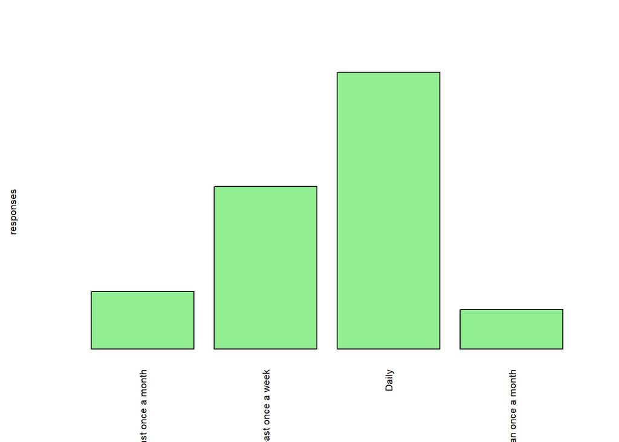

```r
barplot(table(df1$freq_use),ylab = "responses",col = "light green",
      ,srt=45,las=2,yaxt='n',cex.names = 0.65,cex.lab=0.65)
```

What is your role within GVault QDMS?

```r
table(df1$role)
```

```
##
##                   Consumer - Read Only          Document Control Group Member
##                                    153                                     16
## Document Steward for a functional area                               Not Sure
##                                     16                                     18
##                         Owner / Author                    Reviewer / Approver
##                                    142                                    130
```

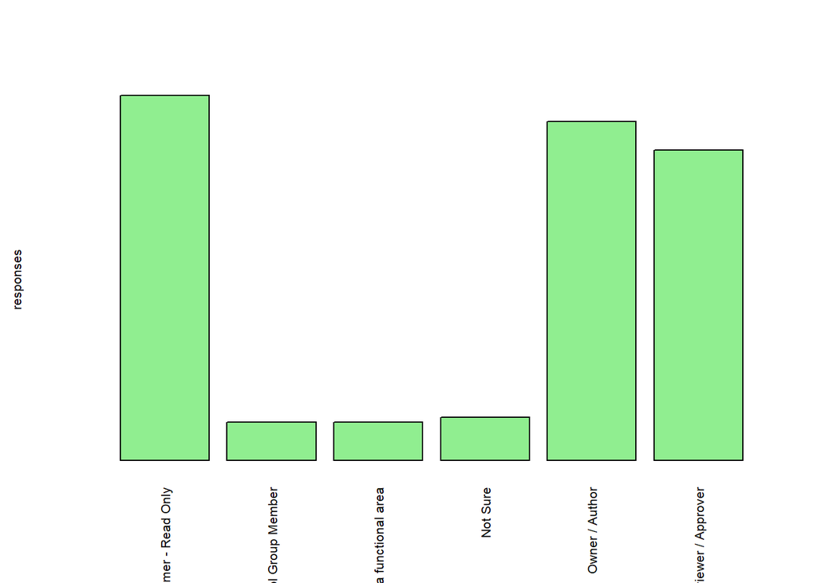

```r
barplot(table(df1$role),ylab = "responses",col = "light green",
        srt=45,las=2,yaxt='n',cex.names = 0.65,cex.lab=0.65)
```

How would you describe the effectiveness of training you received?

```r
table(df1$training_effectiveness)
```

```
##
##               Effective I did not take training    Not effective enough
##                     291                      29                      72
##          Very effective
##                      83
```

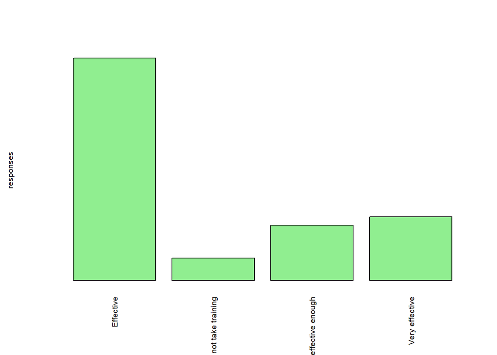

```r
barplot(table(df1$training_effectiveness),ylab = "responses",col = "light green",srt=45,las=2,yaxt='n',cex.names = 0.65,cex.lab=0.65)
```

Are you able to complete work in the system without ‘help’ or ‘intervention’?

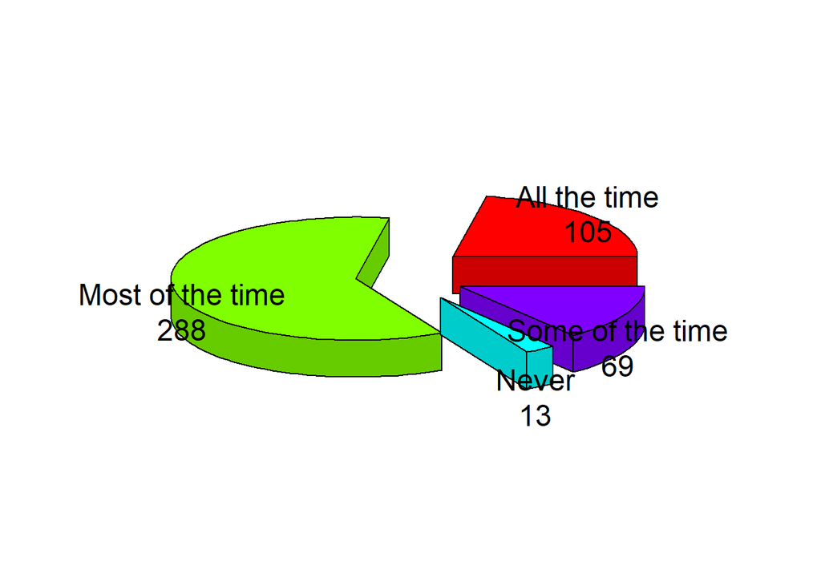

```r
require(plotrix)
mytable=table(df1$complete_without_help)
lbls <- paste(names(mytable), "\n", mytable, sep="")
pie3D(mytable, labels = lbls,explode=0.3)
```

Do you find it easy to search for and access documents in GVault QDMS?

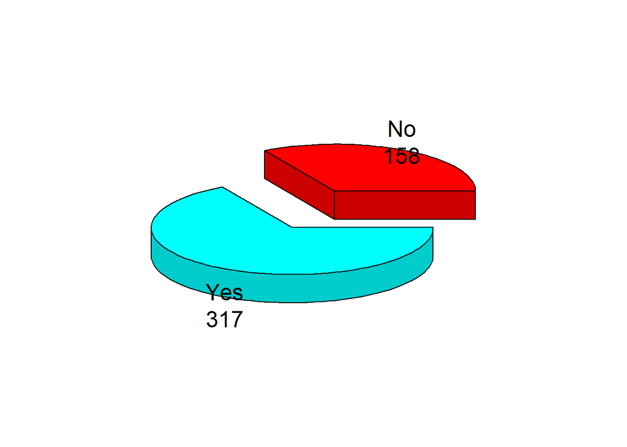

```r
mytable=table(df1$easy_access_documents)
lbls <- paste(names(mytable), "\n", mytable, sep="")
pie3D(mytable, labels = lbls,explode=0.3)
```

How satisfied are you with the overall experience of GVault QDMS?

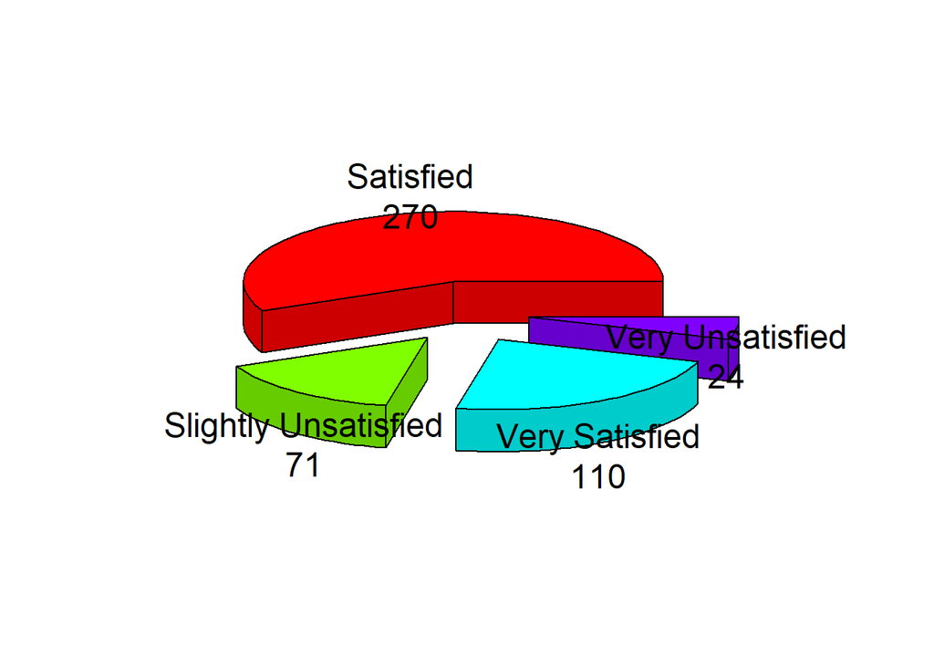

```r
mytable=table(df1$satisfaction)
lbls <- paste(names(mytable), "\n", mytable, sep="")
pie3D(mytable, labels = lbls,explode=0.3)
```

How would you describe your efficiency with GVault as compared to GDocs?

```r
table(df1$Gvault_efficiency)
```

```
##
##                                         Decreased                Increased
##                       18                       75                      270
## No noticeable difference
##                      112
```

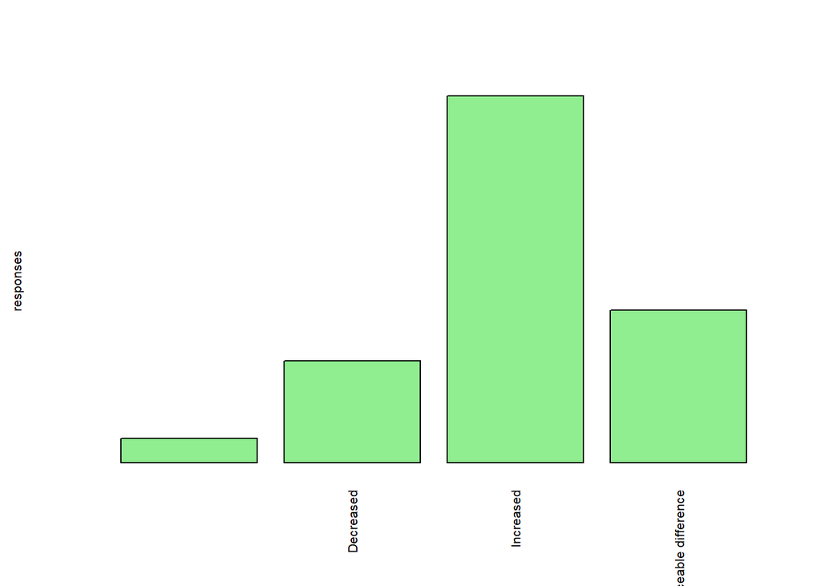

```r
barplot(table(df1$Gvault_efficiency),ylab = "responses",col = "light green",srt=45,las=2,yaxt='n',cex.names = 0.65,cex.lab=0.65)
```

Do you find GVault has improved features and functionality compared to GDocs?

```r
table(df1$Gvault_improved)
```

```
##
##      No Yes
##  28  81 366
```

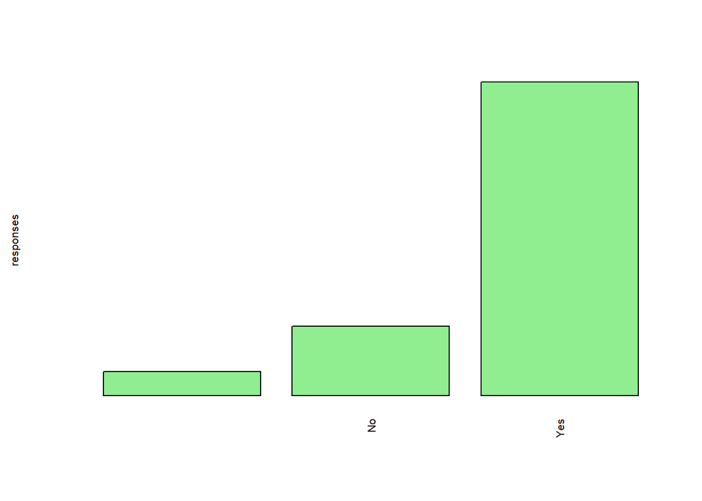

```r
barplot(table(df1$Gvault_improved),ylab="responses",
        col="light green",las=2, yaxt='n',cex.names = 0.65,cex.lab=0.65)
```

### Demographics analysis

What is your functional area?

```r
table(df1$functional_area)
```

```
##
##
##                                                  6
##                                         Commercial
##                                                 12
##                          Facilities and Operations
##                                                 13
##                                            Finance
##                                                  1
##                        Information Technology (IT)
##                                                 70
##                             Other (please specify)
##                                                 37
## Pharmaceutical Development and Manufacturing (PDM)
##                                                217
##                     Research and Development (R&D)
##                                                119
```

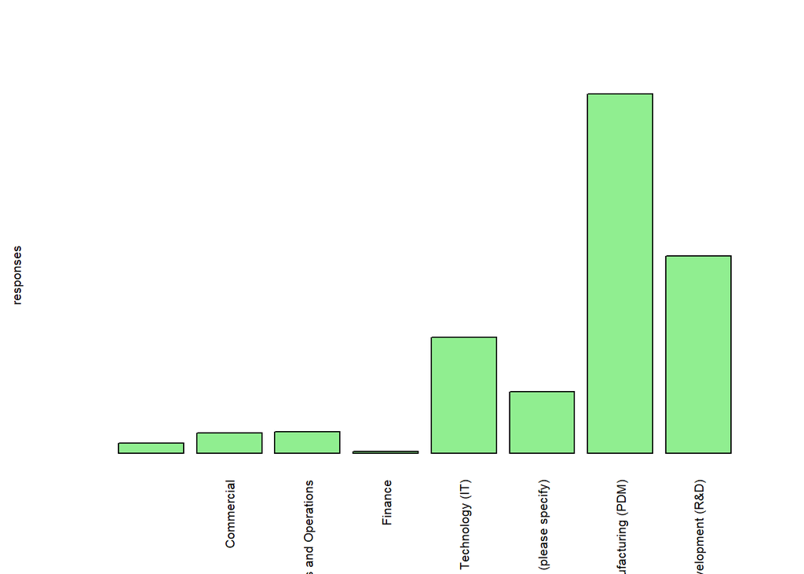

```r
barplot(table(df1$functional_area),ylab = "responses",col = "light green",srt=45,las=2,yaxt='n',cex.names = 0.65,cex.lab=0.65)
```

What is your office location?

```r
table(df1$office_location)
```

```
##
##                                       Alberta              Cambridge
##                      6                     39                     15
##            Cork/Dublin            Foster City              Oceanside
##                     25                    244                     22
## Other (please specify)     San Dimas/La Verne                Seattle
##                     70                     34                     11
##          Stockley Park
##                      9
```

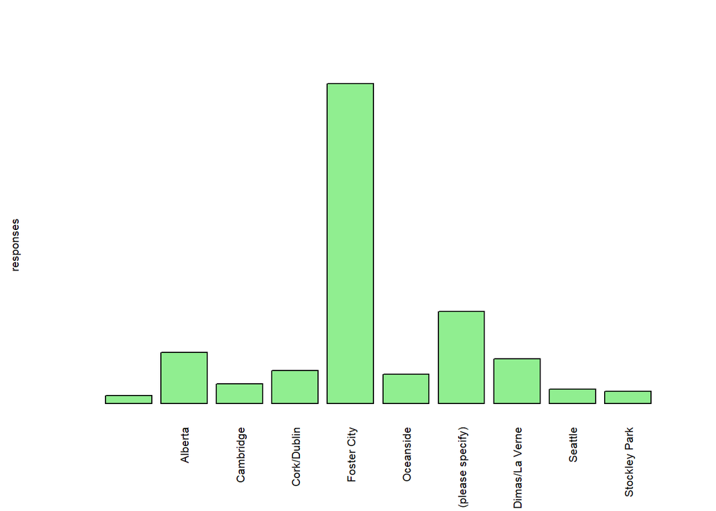

```r
barplot(table(df1$office_location),ylab = "responses",col = "light green",srt=45,las=2,yaxt='n',cex.names = 0.65,cex.lab=0.65)
```

What is your Job Level?

```r
table(df1$job_level)
```

```
##
##                                      Director   Executive Leadership
##                      6                     72                      4
## Individual Contributor Manager / Group Leader Other (please specify)
##                    208                    133                     52
```

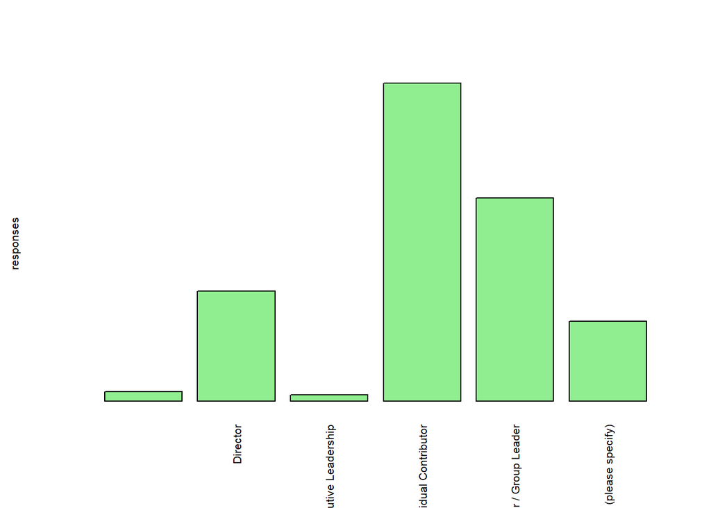

```r
barplot(table(df1$job_level),ylab = "responses",col = "light green",
        srt=45,las=2,yaxt='n',cex.names = 0.65,cex.lab=0.65)
```

How long have you worked at Gilead?

```r
table(df1$time_worked_Glead)
```

```
##
##                          >7 Years     1 to 2 years        3-4 years
##                6              123               73              128
##        5-7 years Less than a year
##               84               61
```

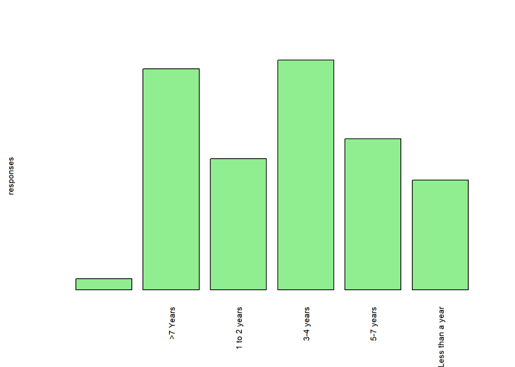

```r
barplot(table(df1$time_worked_Glead),ylab = "responses",col = "light green",srt=45,las=2,yaxt='n',cex.names = 0.65,cex.lab=0.65)
```

### Ordinal Logistic Regression (OLR)

##### Load the Libraries

```r
require(foreign)
```

```r
require(ggplot2)
require(MASS)
require(Hmisc)
require(reshape2)
```

For building this model, we will be using the polr command to estimate an ordered logistic regression. Then, we’ll specify Hess=TRUE to let the model output show the observed information matrix from optimization which is used to get standard errors.

```r
m<-polr(df1$satisfaction ~ df1$freq_use + df1$role
          +df1$training_instructor_led + df1$training_web_based
          + df1$training_read+ df1$no_training+df1$training_effectiveness
          + df1$support_Gnet + df1$support_inapplication
          +df1$support_ref_doc + df1$support_SOP + df1$support_contacted
          +df1$support_IT + df1$complete_without_help
          +df1$easy_access_documents + df1$Gvault_efficiency
          +df1$Gvault_improved,data=df1,Hess=TRUE)
summary(m)
```

```
## Call:
## polr(formula = df1$satisfaction ~ df1$freq_use + df1$role + df1$training_instructor_led +
##     df1$training_web_based + df1$training_read + df1$no_training +
##     df1$training_effectiveness + df1$support_Gnet + df1$support_inapplication +
##     df1$support_ref_doc + df1$support_SOP + df1$support_contacted +
##     df1$support_IT + df1$complete_without_help + df1$easy_access_documents +
##     df1$Gvault_efficiency + df1$Gvault_improved, data = df1,
##     Hess = TRUE)
##
## Coefficients:
##                                                                                                  Value
## df1$freq_useAt least once a week                                                             -0.061256
## df1$freq_useDaily                                                                            -0.225149
## df1$freq_useLess than once a month                                                           -0.298138
## df1$roleDocument Control Group Member                                                        -0.035346
## df1$roleDocument Steward for a functional area                                                0.839250
## df1$roleNot Sure                                                                             -0.710795
## df1$roleOwner / Author                                                                        0.232541
## df1$roleReviewer / Approver                                                                   0.149034
## df1$training_instructor_ledInstructor Led                                                    -0.014088
## df1$training_web_basedWeb/Computer Based                                                     -0.201767
## df1$training_readRead & Understood of Procedural Document(s)                                  0.233305
## df1$no_trainingI did not take training                                                       -2.164934
## df1$training_effectivenessI did not take training                                             2.662338
## df1$training_effectivenessNot effective enough                                                0.418935
## df1$training_effectivenessVery effective                                                      1.469944
## df1$support_GnetGNet                                                                          0.007038
## df1$support_inapplicationIn-Application (GVault)                                              0.672101
## df1$support_ref_docReference Document (User Manual, Reference Guide, Training Material, etc)  0.349751
## df1$support_SOPSOPs and Work Instructions                                                     0.112311
## df1$support_contactedContacted my Document Control or Training Group                         -0.224774
## df1$support_ITIT Support / SPARC                                                              0.062084
## df1$complete_without_helpMost of the time                                                    -0.900815
## df1$complete_without_helpNever                                                                0.499156
## df1$complete_without_helpSome of the time                                                    -0.261270
## df1$easy_access_documentsYes                                                                 -0.162641
## df1$Gvault_efficiencyDecreased                                                                0.925684
## df1$Gvault_efficiencyIncreased                                                                0.813776
## df1$Gvault_efficiencyNo noticeable difference                                                 0.107436
## df1$Gvault_improvedNo                                                                         1.889843
```

[output cut: 57 more lines]

```
## df1$easy_access_documentsYes                                                                 -0.63187
## df1$Gvault_efficiencyDecreased                                                                1.08428
## df1$Gvault_efficiencyIncreased                                                                0.98825
## df1$Gvault_efficiencyNo noticeable difference                                                 0.12949
## df1$Gvault_improvedNo                                                                         2.82023
## df1$Gvault_improvedYes                                                                        0.86269
##
## Intercepts:
##                                     Value   Std. Error t value
## Satisfied|Slightly Unsatisfied       1.6519  0.7826     2.1109
## Slightly Unsatisfied|Very Satisfied  2.4814  0.7885     3.1472
## Very Satisfied|Very Unsatisfied      4.7798  0.8193     5.8342
##
## Residual Deviance: 914.5326
## AIC: 980.5326
```

Now we’ll calculate some essential metrics such as p-Value, CI, Odds ratio. The output displayed next are values: log odds(coefficients of estimation), t values are the t-distribution test statistic values, and finally the p-values are the probability of error.

```r
ctable <- coef(summary(m))
p <- pnorm(abs(ctable[, "t value"]), lower.tail = FALSE) * 2
ctable <- cbind(ctable, "p value" = p)
ctable
```

```
##                                                                                                     Value
## df1$freq_useAt least once a week                                                             -0.061255520
## df1$freq_useDaily                                                                            -0.225148789
## df1$freq_useLess than once a month                                                           -0.298137738
## df1$roleDocument Control Group Member                                                        -0.035346366
## df1$roleDocument Steward for a functional area                                                0.839250212
## df1$roleNot Sure                                                                             -0.710794769
## df1$roleOwner / Author                                                                        0.232540770
## df1$roleReviewer / Approver                                                                   0.149033738
## df1$training_instructor_ledInstructor Led                                                    -0.014088132
## df1$training_web_basedWeb/Computer Based                                                     -0.201766655
## df1$training_readRead & Understood of Procedural Document(s)                                  0.233305064
## df1$no_trainingI did not take training                                                       -2.164933941
## df1$training_effectivenessI did not take training                                             2.662337561
## df1$training_effectivenessNot effective enough                                                0.418934925
## df1$training_effectivenessVery effective                                                      1.469944319
## df1$support_GnetGNet                                                                          0.007037608
## df1$support_inapplicationIn-Application (GVault)                                              0.672101137
## df1$support_ref_docReference Document (User Manual, Reference Guide, Training Material, etc)  0.349751351
## df1$support_SOPSOPs and Work Instructions                                                     0.112310847
## df1$support_contactedContacted my Document Control or Training Group                         -0.224773958
## df1$support_ITIT Support / SPARC                                                              0.062083893
## df1$complete_without_helpMost of the time                                                    -0.900814906
## df1$complete_without_helpNever                                                                0.499156305
## df1$complete_without_helpSome of the time                                                    -0.261270473
## df1$easy_access_documentsYes                                                                 -0.162640886
## df1$Gvault_efficiencyDecreased                                                                0.925683533
## df1$Gvault_efficiencyIncreased                                                                0.813775704
## df1$Gvault_efficiencyNo noticeable difference                                                 0.107435707
## df1$Gvault_improvedNo                                                                         1.889843138
## df1$Gvault_improvedYes                                                                        0.539833742
## Satisfied|Slightly Unsatisfied                                                                1.651903387
## Slightly Unsatisfied|Very Satisfied                                                           2.481428832
## Very Satisfied|Very Unsatisfied                                                               4.779807594
##                                                                                              Std. Error
## df1$freq_useAt least once a week                                                              0.3640076
## df1$freq_useDaily                                                                             0.3642379
## df1$freq_useLess than once a month                                                            0.5118063
## df1$roleDocument Control Group Member                                                         0.5846309
## df1$roleDocument Steward for a functional area                                                0.5560856
```

[output cut: 81 more lines]

```
## df1$support_SOPSOPs and Work Instructions                                                    6.017750e-01
## df1$support_contactedContacted my Document Control or Training Group                         3.088095e-01
## df1$support_ITIT Support / SPARC                                                             8.448912e-01
## df1$complete_without_helpMost of the time                                                    3.949568e-04
## df1$complete_without_helpNever                                                               4.195714e-01
## df1$complete_without_helpSome of the time                                                    4.810755e-01
## df1$easy_access_documentsYes                                                                 5.274724e-01
## df1$Gvault_efficiencyDecreased                                                               2.782395e-01
## df1$Gvault_efficiencyIncreased                                                               3.230284e-01
## df1$Gvault_efficiencyNo noticeable difference                                                8.969693e-01
## df1$Gvault_improvedNo                                                                        4.798950e-03
## df1$Gvault_improvedYes                                                                       3.883099e-01
## Satisfied|Slightly Unsatisfied                                                               3.477958e-02
## Slightly Unsatisfied|Very Satisfied                                                          1.648468e-03
## Very Satisfied|Very Unsatisfied                                                              5.403950e-09
```

#### Odds Ratios and their Confidence Intervals

```r
ci <- confint(m)
exp(cbind(OR = coef(m), ci))
```

```
##                                                                                                      OR
## df1$freq_useAt least once a week                                                              0.9405829
## df1$freq_useDaily                                                                             0.7983974
## df1$freq_useLess than once a month                                                            0.7421991
## df1$roleDocument Control Group Member                                                         0.9652710
## df1$roleDocument Steward for a functional area                                                2.3146308
## df1$roleNot Sure                                                                              0.4912536
## df1$roleOwner / Author                                                                        1.2618019
## df1$roleReviewer / Approver                                                                   1.1607121
## df1$training_instructor_ledInstructor Led                                                     0.9860106
## df1$training_web_basedWeb/Computer Based                                                      0.8172856
## df1$training_readRead & Understood of Procedural Document(s)                                  1.2627666
## df1$no_trainingI did not take training                                                        0.1147575
## df1$training_effectivenessI did not take training                                            14.3297466
## df1$training_effectivenessNot effective enough                                                1.5203414
## df1$training_effectivenessVery effective                                                      4.3489930
## df1$support_GnetGNet                                                                          1.0070624
## df1$support_inapplicationIn-Application (GVault)                                              1.9583478
## df1$support_ref_docReference Document (User Manual, Reference Guide, Training Material, etc)  1.4187147
## df1$support_SOPSOPs and Work Instructions                                                     1.1188606
## df1$support_contactedContacted my Document Control or Training Group                          0.7986967
## df1$support_ITIT Support / SPARC                                                              1.0640516
## df1$complete_without_helpMost of the time                                                     0.4062385
## df1$complete_without_helpNever                                                                1.6473308
## df1$complete_without_helpSome of the time                                                     0.7700726
## df1$easy_access_documentsYes                                                                  0.8498963
## df1$Gvault_efficiencyDecreased                                                                2.5235926
## df1$Gvault_efficiencyIncreased                                                                2.2564115
## df1$Gvault_efficiencyNo noticeable difference                                                 1.1134193
## df1$Gvault_improvedNo                                                                         6.6183304
## df1$Gvault_improvedYes                                                                        1.7157216
##                                                                                                    2.5 %
## df1$freq_useAt least once a week                                                             0.463984624
## df1$freq_useDaily                                                                            0.393674401
## df1$freq_useLess than once a month                                                           0.266853560
## df1$roleDocument Control Group Member                                                        0.298130157
## df1$roleDocument Steward for a functional area                                               0.756901241
## df1$roleNot Sure                                                                             0.131970798
## df1$roleOwner / Author                                                                       0.717716313
## df1$roleReviewer / Approver                                                                  0.673176065
```

[output cut: 38 more lines]

```
## df1$support_GnetGNet                                                                           1.5498643
## df1$support_inapplicationIn-Application (GVault)                                               3.0976786
## df1$support_ref_docReference Document (User Manual, Reference Guide, Training Material, etc)   2.1638272
## df1$support_SOPSOPs and Work Instructions                                                      1.7057883
## df1$support_contactedContacted my Document Control or Training Group                           1.2308936
## df1$support_ITIT Support / SPARC                                                               1.9673261
## df1$complete_without_helpMost of the time                                                      0.6688372
## df1$complete_without_helpNever                                                                 5.4780282
## df1$complete_without_helpSome of the time                                                      1.5909998
## df1$easy_access_documentsYes                                                                   1.4113909
## df1$Gvault_efficiencyDecreased                                                                14.4853373
## df1$Gvault_efficiencyIncreased                                                                12.3340562
## df1$Gvault_efficiencyNo noticeable difference                                                  6.1067697
## df1$Gvault_improvedNo                                                                         27.2439790
## df1$Gvault_improvedYes                                                                         6.5299143
```

### Summary

Most of the predictor variables were not statistically significant in predicting the level of satisfaction with the overall experience of GVault QDMS. Training effectiveness (p-value=0.04688), Support for In application(p-value=0.00401), complete work without(p-value=0.000395) help,and whether Gvault improved features(p-value=0.0.00479) were the variables that significantly affected satisfaction of a user.